# Моделирование экологических ниш BTN1 и BTN2

## Предупреждение

1. В основе анализа база из файла `MtBTN geography 211124.xlsx`.В датасет НЕ вошли литературные данные из базы, которую мы делали к прошлому отчету. Если их включать, то надо искать данные по генотипам раков. Таких точек в той базе всего несколько (судя по всему, часть из них включена в базу, с которой я работаю).
2. Я НЕ включил сюда никаких данных из неопубликованных сборов из Магадана. Причина - разная технология сбора. Можно думать о включении KAR, ON, PLO из сборов 2023 г., но я бы не стал.

Если что-то будем менять, то могут быть довольно сильные изменения в результатах (из-за малого объема выборки).

## Географическое распространение BTN1 и BTN2

Всего обработан материал по 74 точкам (Рис. 1).

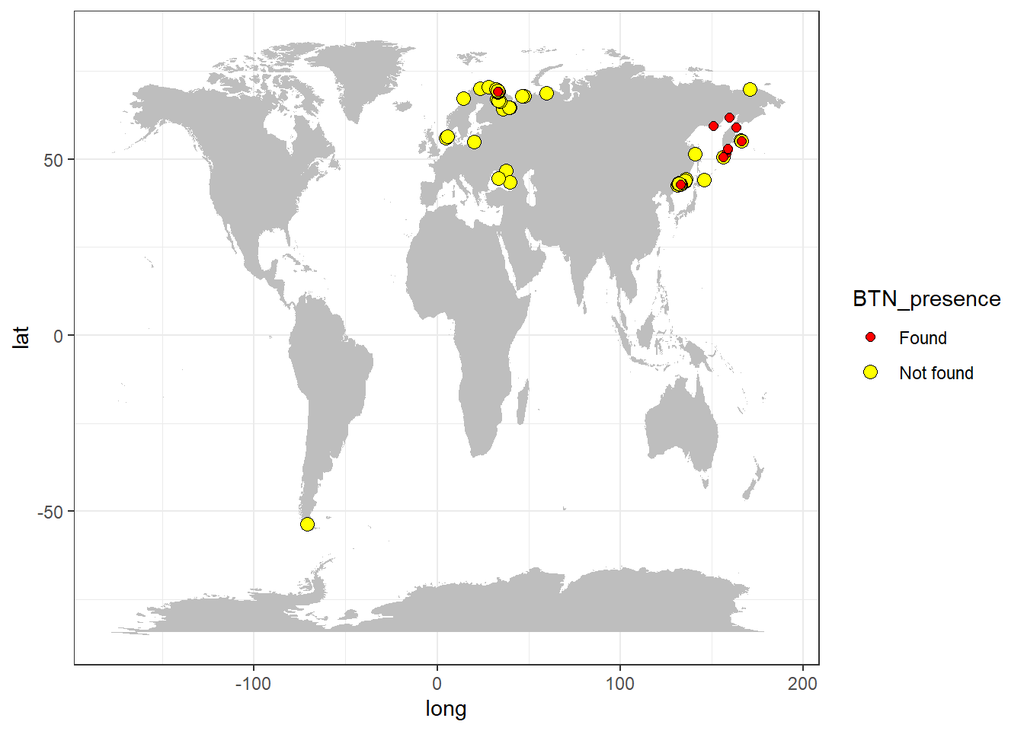

Рис. 1 Расположиение обследованных точек и присутстиве на них BTN

Географическое распространение двух разновидностей раков отражают рис.2.

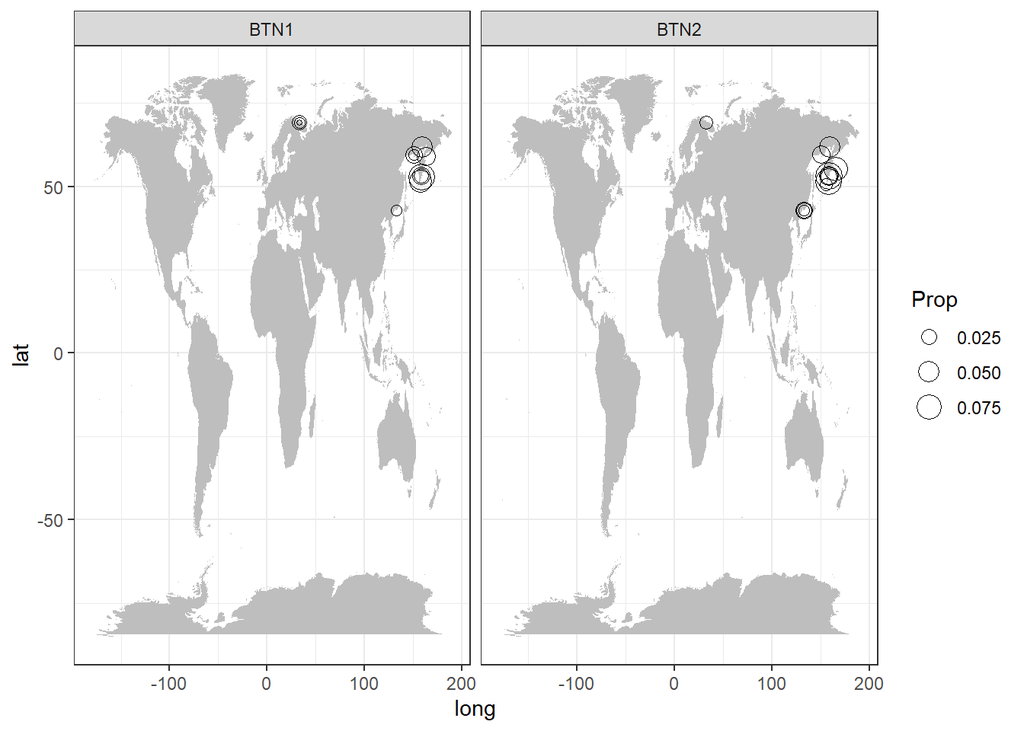

Рис. 2 Частота BTN1 и BTN2 на обследованных учатках

Видно, что более или менее выражено два “гнезда” - (1) Тихоокеанский регион и (2) Баренцево море.

Распределение по регионам было следующим

| Регион | Количество изученных участков | Частота BTN1 в регионе | Частота BTN2 в регионе |
| --- | --- | --- | --- |
| Baltic Sea | 1 | 0.000 | 0.000 |
| Barents Sea | 19 | 0.002 | 0.001 |
| Black Sea | 3 | 0.000 | 0.000 |
| Kamchatka | 6 | 0.036 | 0.042 |
| Komandor islands | 4 | 0.000 | 0.034 |
| Kuril islands | 3 | 0.000 | 0.005 |
| Norwegian Sea | 2 | 0.000 | 0.000 |
| Scotland | 2 | 0.000 | 0.000 |
| Sea of Azov | 1 | 0.000 | 0.000 |
| Sea of Japan | 19 | 0.001 | 0.006 |
| Sea of Okhotsk | 3 | 0.017 | 0.030 |
| White Sea | 9 | 0.000 | 0.000 |
| Восточно-Сибирское море | 1 | 0.000 | 0.000 |
| Магелланов пролив | 1 | 0.000 | 0.000 |

Доля сайтов, на которых отметили BTN1, составила 0.162. Для BTN2 эта велична составила 0.176.

Если принять, что имеющаяся сеть станций более или менее равномерно покрывает широтный градиент побережья Евразии, то можно считать, что частотное распределение широт тех сайтов, где встречены BTN двух разновидностей (Рис. 3), приблизительно отражает их “ареалы”.

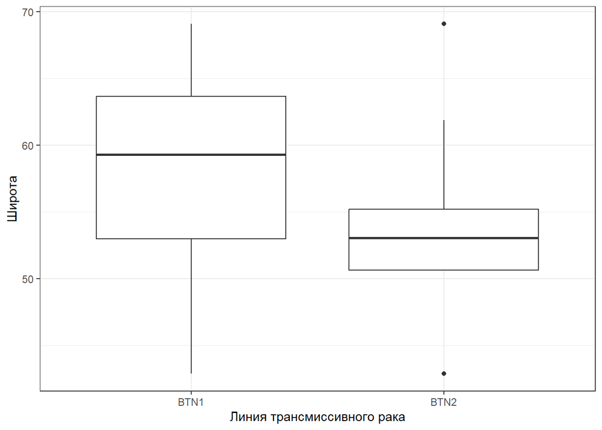

Рис. 3 Распределение географических широт для участков, где встречены BTN1 и BTN2

Ели это не фейк, то видно, что BTN1 - более северный “вид”.

Еще одна закономерность, которая всплывает при анализе данных не из Магадана - это то, что есть некоторая тенденция к более высокой экстенсивности инвазии BTN2 (Рис. 4). Для BTN2 даже можно говорить о бимодальном распределении. Второй пик - это станции, на которых аномально высокая частота заражения. К числу последних относятся следующие станции DD1-35, KOM1, AV2. У BTN1 такой пик выражен слабее.

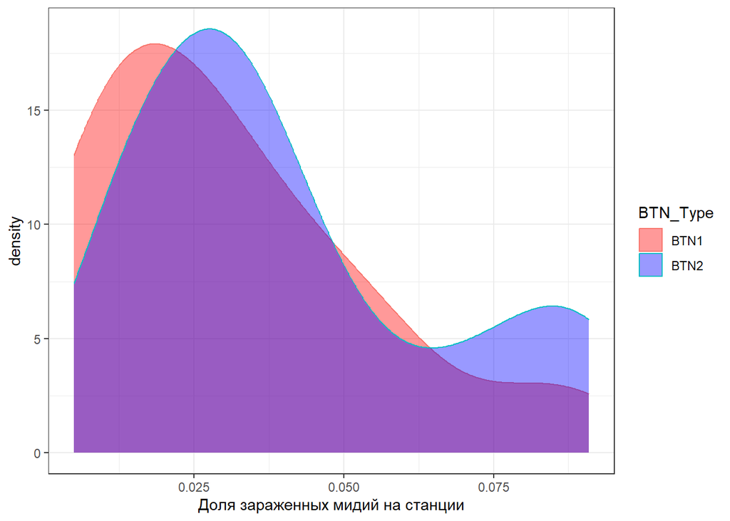

Рис.4 Распределение значений экстенсивности инвазии для двух линий BTN.

## Species distribution model для BTN1 и BTN2

Для этого анализа я взял только точки из Северного полушария.

Значения предикторов были взяты из базы Bio-ORACLE (https://www.bio-oracle.org/). В качестве предикторов для модели были использованы следующие факторы:

- Скорость течения (m/s<sup>-1</sup>)
- Соленость поверхностного слоя воды
- Температура поверхностного слоя воды
- Концентрация хлорофилла (mmol/m<sup>-3</sup>)

Можно было бы надергать еще ряд предикторов (концентрация планктона, силикаты, фосфаты, первичная продукция, нитраты и т.д.), но они все были бы в той или иной степени коллинеарны.

Модель строилась как обобщенная аддитивная модель (GAM). При этом моделирование связи частоты BTN c предикторами пришлось проводить с учетом высокой частоты нулей. Соответственно, в качестве основы было выбрано распределение Твидди (Tweedie distribution). Для подбора модели был использован пакет `mgcv`. Для каждой из разновидностей BTN строили отдельную модель. Это означает, что в качестве порога отвержения нулевой гипотезы был использован уровень $\alpha=$ 0.025.

Таблца 2. Параметры модели, описывающей связь частоты **BTN1** с предикторами

| term | edf | ref.df | statistic | p.value |
| --- | --- | --- | --- | --- |
| s(current) | 0.8319238 | 9 | 0.2361959 | 0.0777444 |
| s(sal) | 0.7951275 | 9 | 0.2406469 | 0.0912004 |
| s(temper) | 0.9524016 | 9 | 0.4877053 | 0.0197200 |
| s(chl) | 1.1677607 | 9 | 0.9819975 | 0.0014001 |

Для BTN1 cтатистически значимыми были отрицательная связь с температурой и положительная с концентрацией хлорофилла (Табл. 2, Рис. 5). Связь с температурой хорошо согласуется с приведенными выше данными о более северном распространении BTN1.

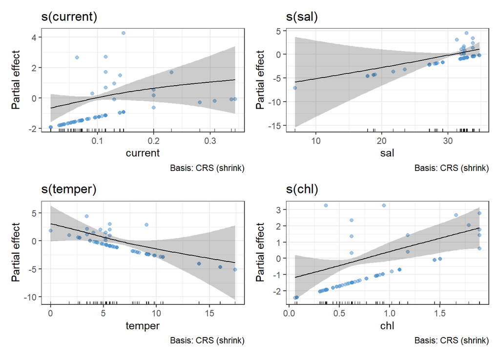

Рис. 5. Связь частоты BTN1 с предикторами

Можно обсуждать также некоторую тенденцию к положительной связи частоты BTN1 со скоростью течения и соленостью (Рис. 5).

Таблца 3. Параметры модели, описывающей связь частоты **BTN2** с предикторами

| term | edf | ref.df | statistic | p.value |
| --- | --- | --- | --- | --- |
| s(current) | 0.0000074 | 9 | 0.0000001 | 0.7287038 |
| s(sal) | 2.1328546 | 9 | 0.6557519 | 0.0502726 |
| s(temper) | 0.0000008 | 9 | 0.0000000 | 0.7523188 |
| s(chl) | 1.1223669 | 9 | 0.9389531 | 0.0026603 |

Для BTN2 cтатистически значимой была лишь положительная с концентрацией хлорофилла (Рис. 6). Можно говорить о некоторой тенденции к положиетльной связи с соленостью.

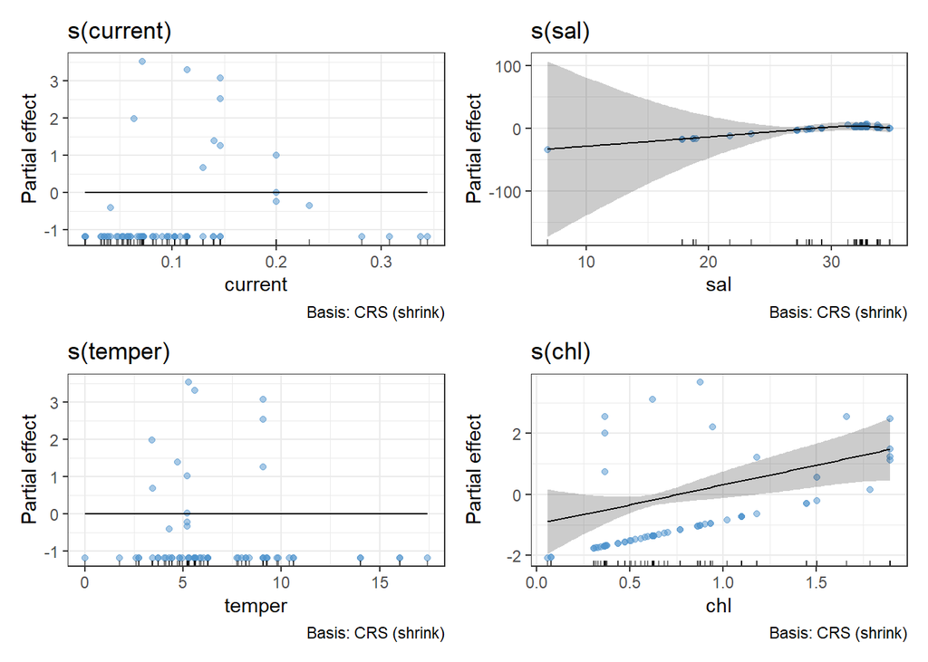

Таким образом, обе линии рака тяготеют к областям с более высокой биологической продуктивностью, которую маркирует высокая концентрация хлорофилла. Возможные причины: там много мидий, там мидии нажористее и т.д.

Если связь со скоростью течения не является фейком, то это хорошо вяжется с тем, что в Магадане BTN1 связан с fetch. Связь с соленостью тоже было бы приятно считать не фейком.

Выявление большего количества значимых связей BTN1 с предикторами можно, наверное, трактовать, как более высокую стенобионтность этой линии рака. Для этой линии больше лимтирующих факторов. BTN2 - более эврибионтная линия.

### Возможные перспективы для дальнейшего анализа

- Включить в датасет данные по Европейским участкам из работы Hammel M. et al. 2023. Если я все правильно понимаю, то там был только BTN2. Это лишь усилит картинку его более южного ареала.
- Построить, все-таки, общую SDM для всех частот DN. То есть взять прошлогоднюю базу данных и построить модель по всем наблюдениям DN. Да, это будет смесь линий, но по мне так тоже можно и интересно. Тут, правда, будет по сравнению с тем, что мы анализируем сейчас, серьезная проблема - это ведь данные где раки встречены, а где они НЕ встречены в базе не отмечено. Так что это не самая хорошая идея. Но думать о ней можно.